# Lecture 11: Line Graphs

Nick Huntington-Klein

05 May, 2020

## As Class Continues!

- What else do we have in class?
- We’re going to cover Tableau
- And also get in plenty of practice
- And we will cover some best-practices for common data communication issues
- Plus our project!

## As Class Continues

- Today and next time we’ll be focusing on two common graph types
- Line graphs today and scatterplots next time
- We will discuss some best-practices, tips and tricks
- And then try them out ourselves more directly

## As Class Continues

- Then we’ll dip into Tableau for a bit, and come back out to focus on more graph types
- At that point class will be a bit of lecture at the start to cover some ground
- And then hands-on work with data and visualization
- There’s no substitute for “getting a feel for it.”

## Line Graphs

- Line graphs: for what?
- Line graphs are good for one-to-one relationships between the x and y axis
- One x in, one y out $\rightarrow$ a bunch of x in, one line out
- Almost always x is in consistent discrete jumps (i.e. 1 2 3 not 1 3 100)
- Often, x is time

## Line Graphs

- What kind of stories can we tell with line graphs?
- Change over time
- When change occurred
- How different groups change (multiple line graphs on the same axes)

## Aesthetics

- How can we draw focus with line graphs (and what stories get told)?
- Color, size, linetype
- Select colors to tell a story (bad = red/good = blue perhaps)
- Data points
- Highlighting
- Vertical and horizontal lines
- Callouts

## Color, Size, Linetype

- These are ways of distinguishing multiple lines
- Dashed generally indicates “less” - less important, less certain

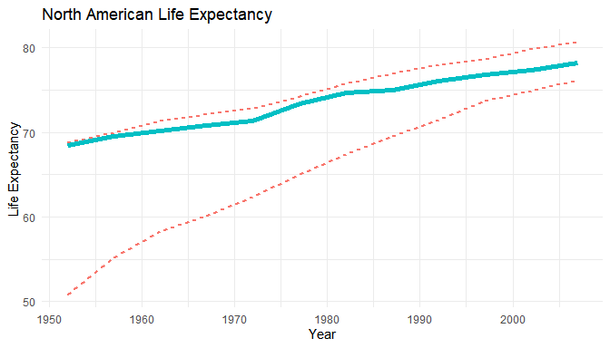

## Colors tell a story too

- Consider color choice for “good” or “bad” messages
- We also add a callout here too

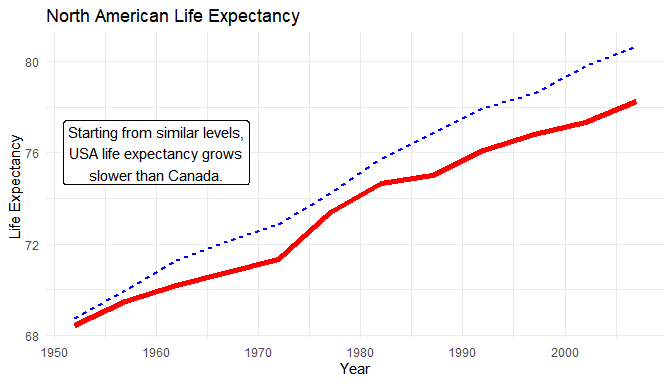

## Labeling Data Points

- Don’t necessarily go whole-hog, but think about what’s important and maybe label that!

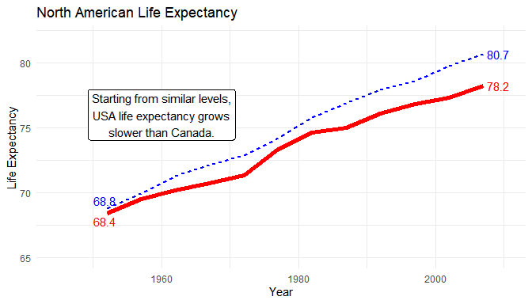

## Labeling Lines

- Rather than a legend, I almost 100% of the time put the title of a line somewhere on the line itself

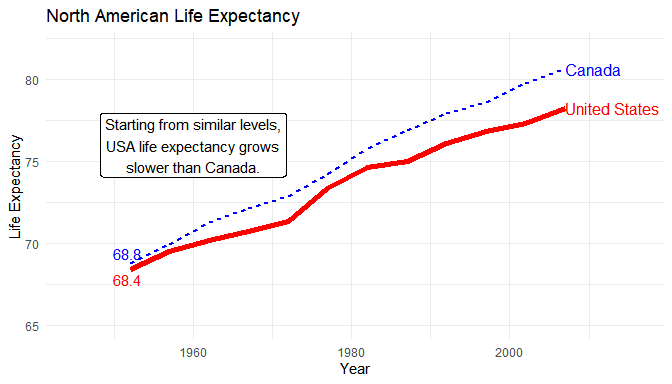

## Highlighting

- Lots of lines is tricky, but if you do do it, it NEEDS highlighting

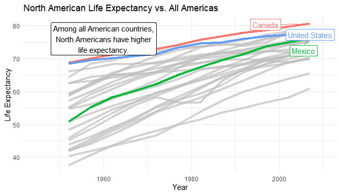

## Vertical and Horizontal Lines

- Very easy ways to read a split in time, or crossing a threshold

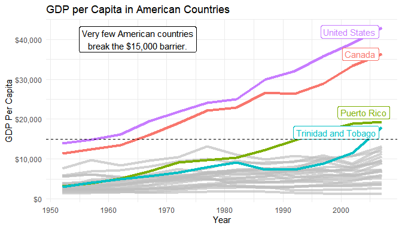

## Vertical and Horizontal Lines

- Very easy ways to read a split in time, or crossing a threshold

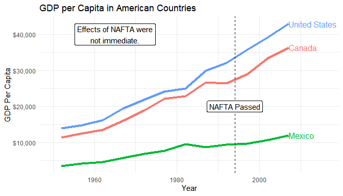

## Common Pitfalls

- What are some common pitfalls?
- Too many lines
- Overlapping lines
- Legends
- Huge range in the y-axis (or too little range)
- Multiple y-axes
- An unordered x-axis (don’t use a line graph for bar graph jobs!)
- Curved lines can give illusion of continuity if it’s not there

## Excel Line Graphs

- Each line in its own column
- If you want to specify an x-axis, use a scatterplot with line connections instead of a line graph
- Use data labels with “Series Labels” on the last/first points to label the lines themselves
- Consider labeling some of the points - “Data labels” for values (make sure to format nicely!), “Data callouts” to also show x-axis
- Explore the different kinds - some show multiple lines as proportions, some stack…

## ggplot2 Line Graphs

- `geom_line()`, perhaps add dots with `geom_point`
- Add vertical and horizontal markers with `geom_vline` and `geom_hline`
- `directlabels` and `geom_dl` for labeling the lines
- Or `gghighlight` to gray out some lines and label the others
- `geom_text` to label the points, use `vjust` or `geom_text_repel` to move out of the way of the line

## Practice

- Download this file of robocall complaints to the FCC: https://www.kaggle.com/fcc/robocall-complaints
- Load the CSV into R using `read_csv` and use dplyr to:
- Keep only Methods of “Wireless (cell phone/other mobile device)” or “Wired”
- Use `mutate` and `case_when` to rename the Wireless Method more reasonably
- Use the `mdy` function in **lubridate** to turn `` `Date of Issue` `` into a date
- Get the number (`n()`) of complaints **by** Date of Issue and Methods
- Write the result as a CSV with `write_csv()`.

## Practice Answers

```r
library(tidyverse); library(lubridate)
df <- read_csv('CGB_-_Consumer_Complaints_Data.csv')
df <- df %>%
  filter(Method %in% c('Wireless (cell phone/other mobile device)','Wired')) %>%
  mutate(Method = case_when(Method == 'Wired' ~ Method, TRUE ~ 'Wireless'),
         `Date of Issue` = mdy(`Date of Issue`)) %>%
  group_by(`Date of Issue`, Method) %>%
  summarize(`Number of Complaints` = n())
write_csv(df,'robocalls.csv')
```

## Replicate a Graph

- For this replication we’ll be using smoothed data
- Since this daily data staggers up and down very quickly and is hard to see
- This works well when we want to look at things from a farther-back perspective
- But can be iffy if it lets us cover up actual non-smooth changes in the data

## Replicate this Graph!

- Working with **ggplot2**, and only keeping dates between Jan 1 2014 and Sept 12 2017 (hint: `mdy('01-01-2014')` and `mdy('09-12-2017')` from **lubridate**), and using `geom_smooth(se=FALSE)` and the `lisa::GeneDavis` palette, replicate this graph

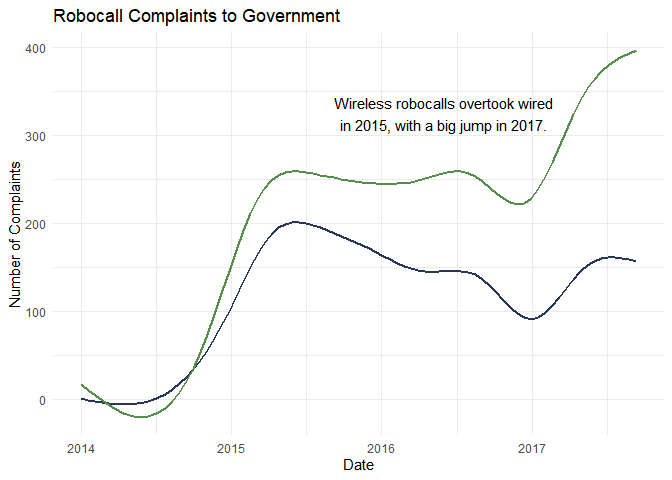

## Replicate This Graph!

```r
ggplot(df %>% filter(`Date of Issue` >= mdy('01-01-2014') & `Date of Issue` <= mdy('09-12-2017')),
       aes(x = `Date of Issue`,y = `Number of Complaints`, color = Method)) +
  geom_smooth(se=FALSE) +
  theme_minimal() +
  guides(color = FALSE) +
  annotate(geom='text', x = mdy('06-01-2016'),y=325, label = 'Wireless robocalls overtook wired\nin 2015, with a big jump in 2017.') +
  labs(x = 'Date',title = 'Robocall Complaints to Government') +
  scale_color_paletteer_d('lisa::GeneDavis')
```

## Practice Graphing

- Now, working with Excel, again cut to between Jan. 1 2014 and Sept. 12 2017.
- You’ll have to do a little data manipulation by hand, and a pivot chart

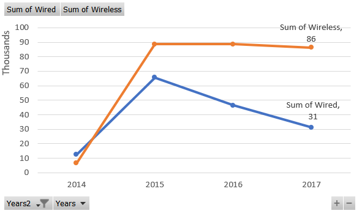

## Graphing

- Now with whatever time we have left, see if you can come up with another interesting graph! Excel or **ggplot2**